# R-eggueton viejo y nuevo: ¿Utiliza palabras misóginas?

Realizado por Scarlett Escudero

8/03/2022

Se suele decir que el reggueton es más progresivo y menos misógino hoy en día que en sus orígenes. Decidimos analizar esta afirmación mediante el análisis de las canciones de 4 artistas del género regguetón: Bad Bunny, J Balvin, Daddy Yankee y Wisin y Yandel. Los dos primeros siendo artistas más recientes de este género y los dos últimos con mayor trayectoria musical.

Spotify tiene datos como la baileabilidad (danceability), energía (energy) y valencia (valence) de cada canción en su plataforma. La baileabilidad se refiere a qué tan baileable es una canción, la energía es qué tan enérgica es la canción y la valencia es el grado de positividad (o negatividad) de la canción. Los dos primeros se miden en una escala de 0 a 1, donde 1 es el grado máximo de baileabilidad y energía. La valencia se mide en una escala de 0 a 1, donde 1 es una canción positiva y 0 una canción negativa.

La media de baileabilidad, energía y valencia promedio de cada artista es:

| Artista | Baileabilidad | Energía | Valencia |
| --- | --- | --- | --- |
| Bad Bunny | 0.744 | 0.664 | 0.514 |
| J Balvin | 0.740 | 0.704 | 0.6824 |
| Daddy Yankee | 0.710 | 0.798 | 0.675 |
| Wisin y Yandel | 0.741 | 0.785 | 0.587 |

## Bad Bunny

Las canciones de Bad Bunny con valencia más alta, es decir, más positiva son:

| Canción | Valencia |
| --- | --- |
| CANTARES DE NAVIDAD | 0.962 |
| UN PESO | 0.961 |
| QUE PRETENDES | 0.939 |
| SI ELLA SALE | 0.920 |
| A Tu Merced | 0.887 |
| MOJAITA | 0.885 |
| Está Cabrón Ser Yo | 0.879 |
| BENDICIONES | 0.843 |
| Si Veo a Tu Mamá | 0.824 |
| COMO UN BEBÉ | 0.816 |

Asimismo, las canciones de Bad Bunny con valencia más baja, es decir, más negativa son:

| Canción | Valencia |
| --- | --- |
| TE DESEO LO MEJOR | 0.1940 |
| Soliá | 0.1840 |
| Ser Bichote | 0.1830 |
| Si Estuviésemos Juntos | 0.1580 |
| MIA | 0.1560 |
| Solo de Mi | 0.1500 |
| DÁKITI | 0.1450 |
| Tenemos Que Hablar | 0.1440 |
| RLNDT | 0.1420 |
| TRELLAS | 0.0508 |

La baileabilidad y valencia de los álbumes de Bad Bunny son los siguientes:

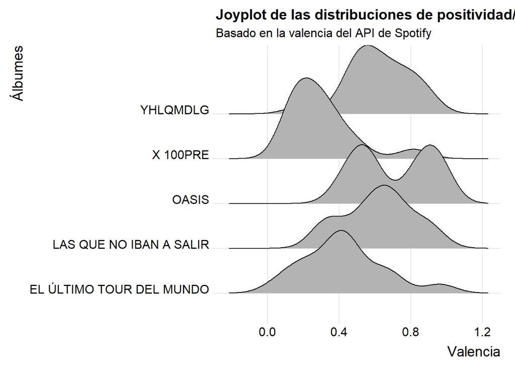

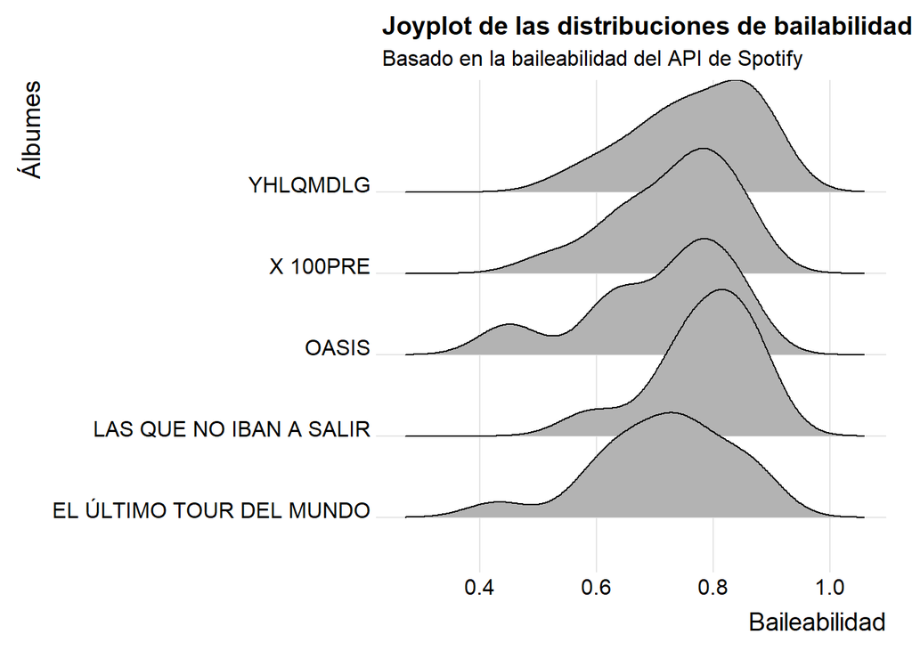

## J Balvin

Las canciones de J Balvin con valencia más alta, es decir, más positiva son:

| Canción | Valencia |
| --- | --- |
| 6 AM - Merengue Remix | 0.965 |
| 6 AM - Merengue Remix | 0.965 |
| Amarillo | 0.961 |
| UN PESO | 0.961 |
| Eras Así | 0.961 |
| Eras Así | 0.961 |
| Yo Te Lo Dije | 0.961 |
| Eras Así | 0.961 |
| Acércate | 0.959 |
| Yo Te Lo Dije | 0.957 |

Asimismo, sus canciones con valencia más baja, es decir, más negativa son:

| Canción | Valencia |
| --- | --- |
| Sola | 0.3870 |
| Rosa | 0.3690 |
| Sola | 0.3570 |
| In Da Getto - TSHA Remix | 0.3550 |
| Ganas De Verte | 0.3460 |
| Ganas De Verte | 0.3450 |
| Ganas De Verte | 0.3310 |
| Mi Gente | 0.2880 |
| Vibras | 0.1190 |
| En Mí (Interlude) | 0.0634 |

La baileabilidad y valencia de los álbumes de J Balvin son los siguientes:

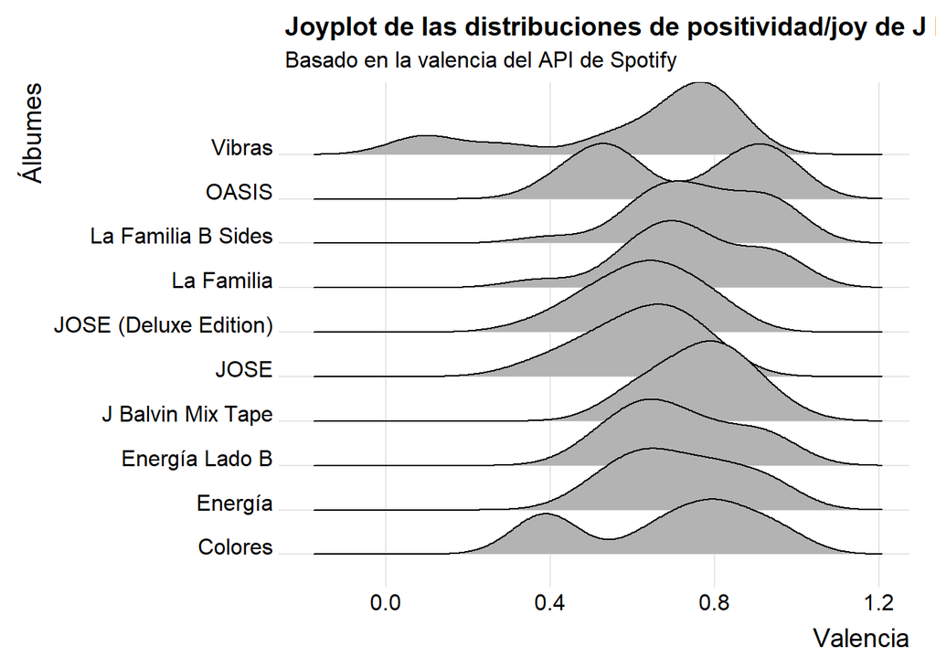

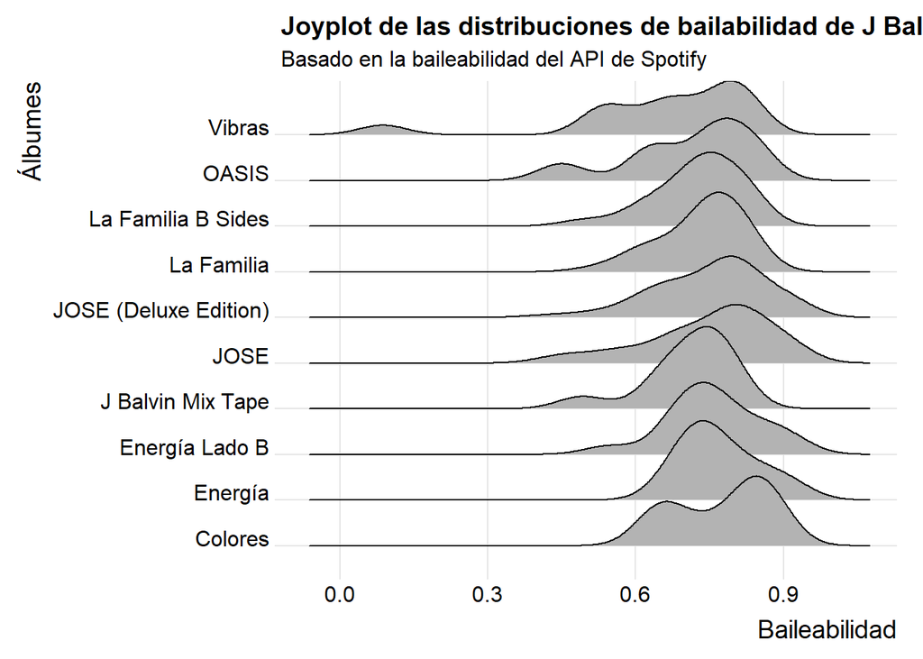

## Daddy Yankee

Las canciones de Daddy Yankee con valencia más alta, es decir, más positiva son:

| Canción | Valencia |
| --- | --- |
| La Despedida | 0.972 |
| La Despedida | 0.972 |
| Le Gusta a la Mujer | 0.968 |
| Oasis de Fantasia | 0.966 |
| Como Dice Que Dijo (skit) | 0.965 |
| La Señal | 0.962 |
| La Señal | 0.962 |
| Sabor a Melao - Remix (Bonus Track) | 0.962 |
| Que Tengo Que Hacer - Live | 0.959 |
| El Truco - Live | 0.958 |

Asimismo, las canciones de Daddy Yankee con valencia más baja, es decir, más negativa son:

| Canción | Valencia |
| --- | --- |
| Gasolina - Live | 0.0813 |
| Gasolina - Live | 0.0788 |
| Intro - Live | 0.0675 |
| Interlude - Live | 0.0000 |
| Interlude - Live | 0.0000 |
| Interlude - Live | 0.0000 |
| Interlude - Live | 0.0000 |
| Interlude - Live | 0.0000 |
| Interlude - Live | 0.0000 |
| Interlude - Live | 0.0000 |

La baileabilidad y valencia de los álbumes de Daddy Yankee son los siguientes:

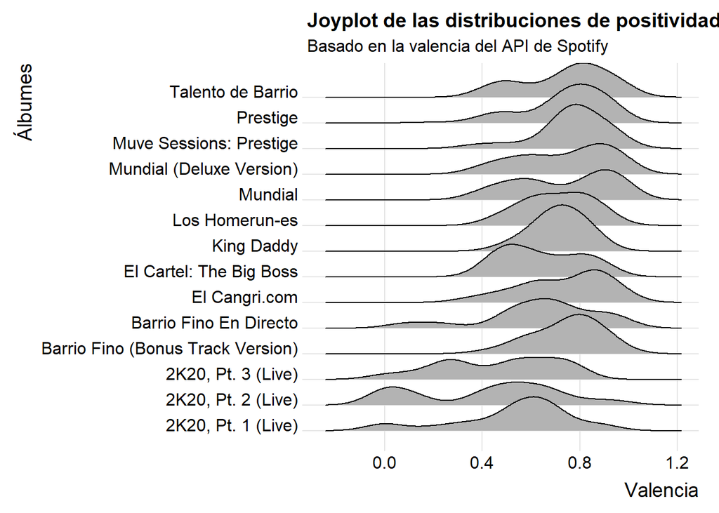

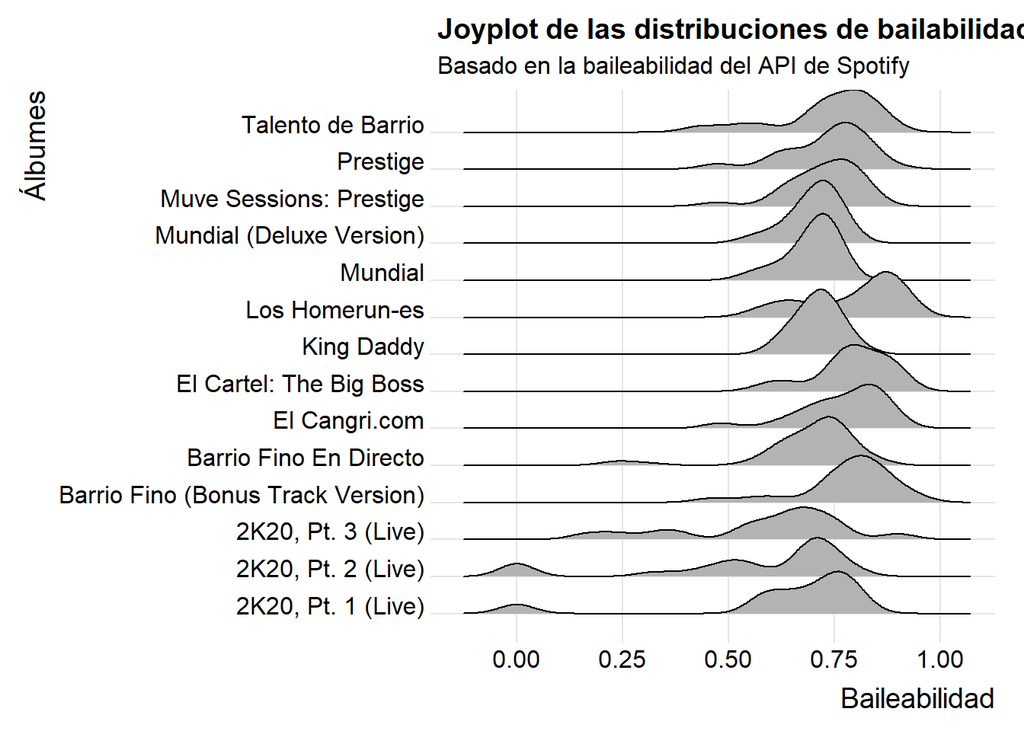

## Wisin y Yandel

Las canciones de Wisin y Yandel con valencia más alta, es decir, más positiva son:

| Canción | Valencia |
| --- | --- |
| Porque Me Peleas | 0.963 |
| Salgo Filoteau | 0.961 |
| Salgo Filoteau | 0.961 |
| Dime por Qué | 0.945 |
| Rakata - Tigerstyle Eastern Remix | 0.941 |
| Dime Quienes Son | 0.931 |
| Dime Quienes Son | 0.931 |
| Dime Quienes Son | 0.929 |
| Prende | 0.914 |
| Prende | 0.914 |

Las canciones de Wisin y Yandel con valencia más baja, es decir, más negativa son:

| Canción | Valencia |
| --- | --- |
| Abusadora | 0.190 |
| Abusadora - Live At Coliseo Jose Miguel Agrelot, Puerto Rico/2010 | 0.185 |
| Abusadora - Live At Coliseo Jose Miguel Agrelot, Puerto Rico/2010 | 0.185 |
| Esta Noche Hay Pelea | 0.177 |
| Intro Mi Vida | 0.163 |
| Algo Me Gusta De Ti | 0.161 |
| Abusadora | 0.160 |
| Algo Me Gusta De Ti | 0.154 |
| Algo Me Gusta De Ti | 0.154 |
| Intro - Tomando Control - Live | 0.147 |

La baileabilidad y valencia de los álbumes de Wisin y Yandel son los siguientes:

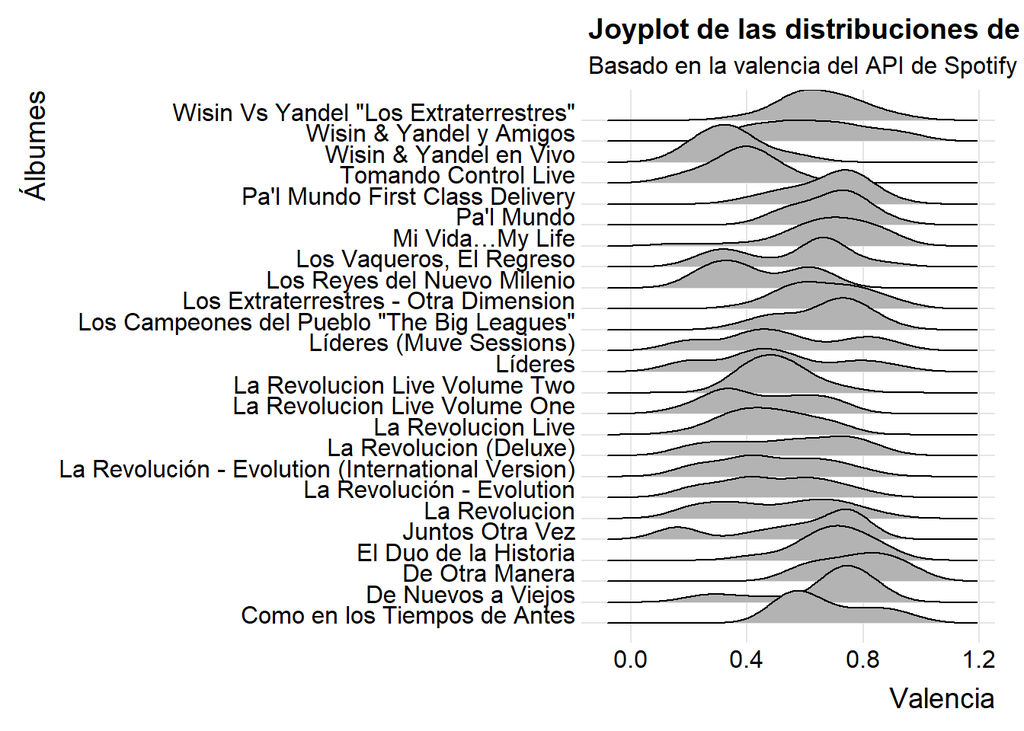

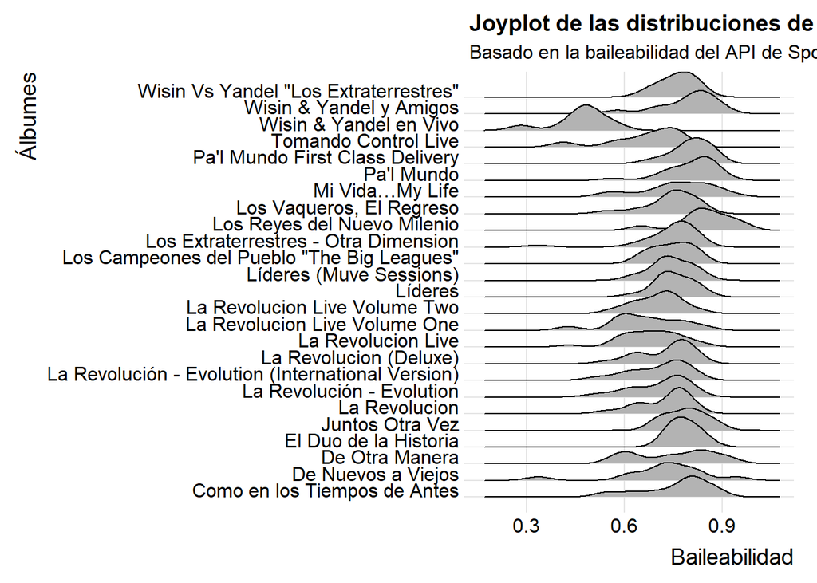

# Frecuencia de palabras en la letra de las canciones más populares de los artistas

Se analizó la frecuencia de palabras que aparecen en las 10 canciones más populares en México de cada artista, de acuerdo con la lista de Spotify. Esta lista se obtuvo el 4 de marzo de 2022.

## Bad Bunny

Las top 10 canciones de Bad Bunny son:

1. “Lo Siento BB:/” - Tainy ft. Bad Bunny & Julieta Venegas
2. “Yonaguni” - Bad Bunny
3. “Volví” - Aventura ft. Bad Bunny
4. “Volando - Remix” - Mora ft. Bad Bunny & Sech
5. “A Tu Merced” - Bad Bunny
6. “LA CANCIÓN” - Bad Bunny ft. J Balvin
7. “AM Remix” - Nio García ft. J Balvin & Bad Bunny
8. “La Santa” - Bad Bunny
9. “DÁKITI” - Bad Bunny ft. Jhay Cortez
10. “Si Estuviésemos Juntos” - Bad Bunny

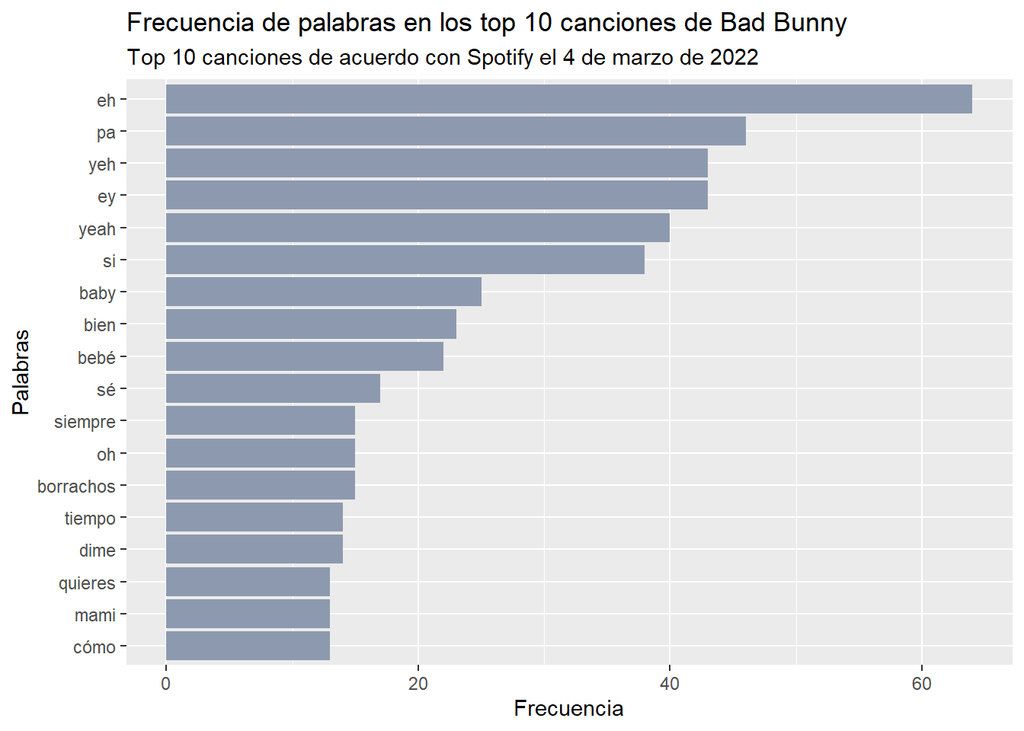

### J Balvin

Se tomaron las 10 canciones más populares en México de J Balvin de acuerdo con Spotify el 4 de marzo de 2022. Las canciones son: 1. “LA CANCIÓN” - Bad Bunny ft. J Balvin  
2. “AM Remix” - Nio García ft. J Balvin & Bad Bunny  
3. “Qué Más Pues?” - J Balvin ft. María Becerra  
4. “Una Nota” - J Balvin ft. Sech  
5. “In Da Getto” - J Balvin ft. Skrillex 6. “I Like It” - Cardi B ft. Bad Bunny & J Balvin 7. “No Me Conoce - Remix” - Jhay Cortez ft. J Balvin & Bad Bunny 8. “QUE PRETENDES” - J Balvin ft Bad Bunny 9. “UN DIA (ONE DAY)” - J Balvin ft. Dua Lipa & Bad Bunny & Tainy 10. “Una Locura” - Ozuna ft. J Balvin & Chencho Corleone

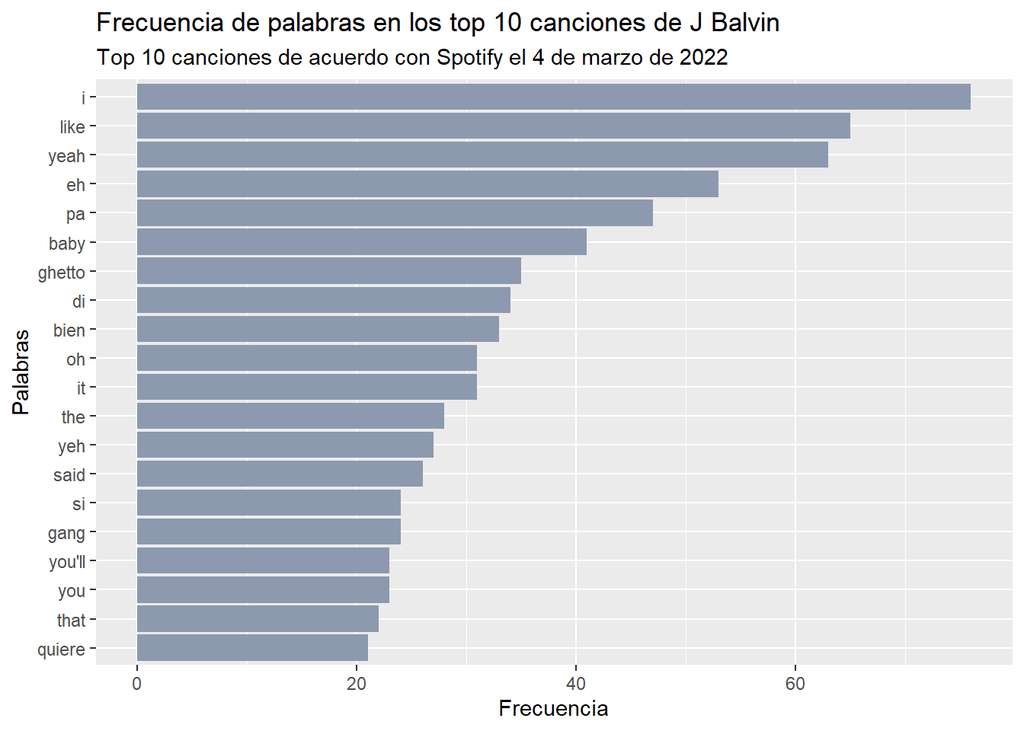

### Daddy Yankee

Se tomaron las 10 canciones más populares en México de Daddy Yankee de acuerdo con Spotify el 4 de marzo de 2022. 1. “La Santa” - Bad Bunny ft. Daddy Yankee  
2. “Despacito” - Luis Fonsi ft. Daddy Yankee  
3. “Con Calma” - Daddy Yankee ft. Snow  
4. “Gasolina” - Daddy Yankee  
5. “Relación - Remix” - Sech ft. Daddy Yankee, J Balvin, ROSALÍA & Farruko 6. “China”- Anuel AA ft. Daddy Yankee, Karol G, Ozuna & J Balvin  
7. “Baila Baila Baila - Remix” - Ozuna ft. Daddy Yankee, J Balvin, Farruko & Anuel AA 8. “Soltera - Remix” - Lunay ft. Daddy Yankee & Bad Bunny 9. “Lo Que Pasó, Pasó” - Daddy Yankee  
10. “Sal y Perrea - Remix” - Sech ft. Daddy Yankee & J Balvin

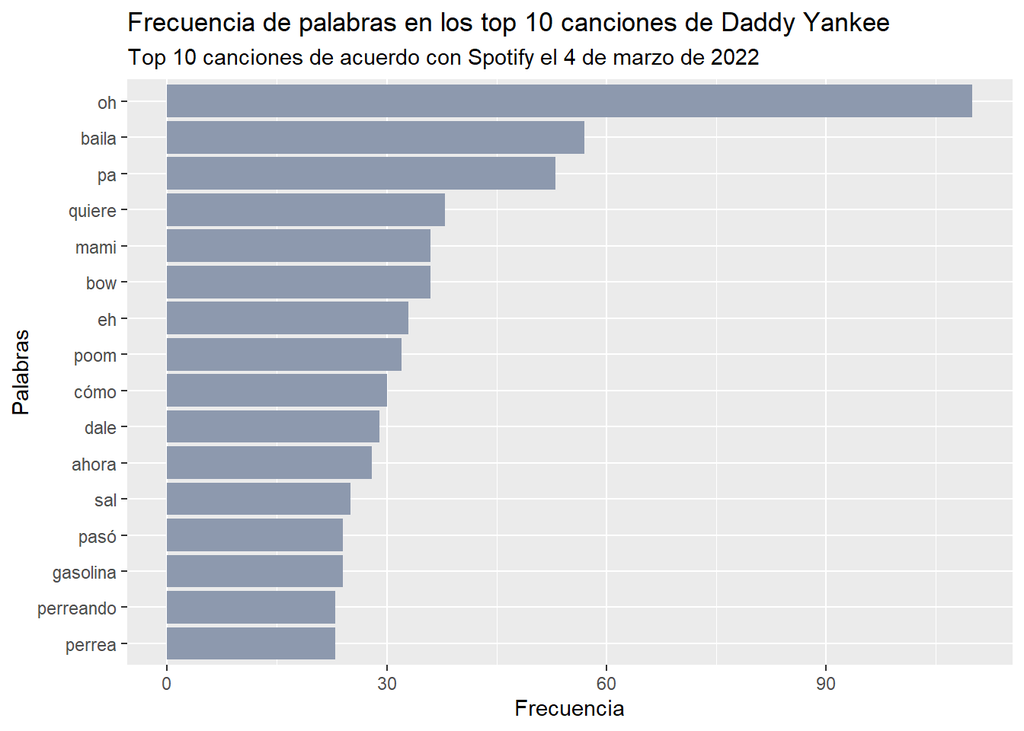

### Wisin y Yandel

Se tomaron las 10 canciones más populares en México de Wisin y Yandel de acuerdo con Spotify el 4 de marzo de 2022.

1. “Algo Me Gusta De Ti” - Wisin y Yandel ft. Chris Brown & T Pain
2. “Noche De Sexo” - Wisin y Yandel ft. Romeo Santos
3. “Aullando” - Wisin y Yandel ft. Romeo Santos
4. “NO SE OLVIDA” - Wisin y Yandel
5. “Rakata” - Wisin y Yandel
6. “LEYENDAS” - Karol G ft. Wisin y Yandel, Nicky Jam, Ivy Queen, Zion & Alberto Stylee
7. “Sexy Movimiento” - Wisin y Yandel
8. “Si Supieras” - Daddy Yankee ft. Wisin y Yandel
9. “Noche De Entierro” - Daddy Yankee ft. Wisin y Yandel, Zion, Hector & Tony Tun Tun
10. “Mala Costumbre” - Manuel Turzio ft. Wisin y Yandel

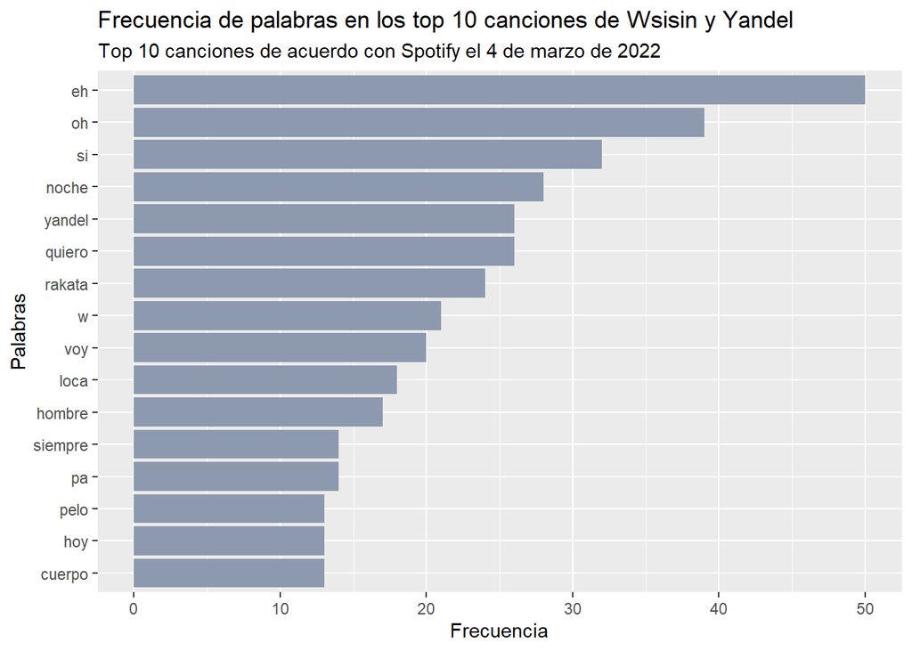

# Conclusiones

En cuanto a la media de la baileabilidad, energía y valencia en promedio de los 4 artistas, encontramos que son muy similares. Esto con la excepción de Bad Bunny que tiene una energía ligeramente más baja en comparación con los demás. El álbum de “X 100PRE” de Bad Bunny, “2K20 parte 2” de Daddy Yankee y “Wisin y Yandel y Amigos” y “Wisin y Yandel en vivo” de Wisin y Yandel parecen tener la menor positividad en comparación del resto de sus álbumes.

En cuanto a la frecuencia de palabras, podemos observar que en 3 de 4 artistas las palabras *baby*, *bebé* y *mami* son de las principales repetidas. Estas palabras en el contexto de las canciones tienen una connotación de infantilización de la mujer (las primeras dos) y sexualización de la mujer(en el caso de mami). Otras palabras suelen tener un tono sexual, como es el caso de *rakata*, *gasolina*,*cuerpo* y *poom¨*.

Una posible razón a la falta de datos conclusivos es que las top 10 canciones incluyen traslapes entre los 4 artistas e incluso con otros artistas y su propia letra. Los compositores y cantantes cambian constantemente en la mayoría de las canciones. En el caso de J Balvin, ninguna de sus top 10 canciones era una donde sólo participara él.